# Assessment 7: Regularization and Advanced Classification

**Name:** Atasha Samantha Tadeo Geronimo  
**Section:** 2DSA2  
**Course:** DSA4155: Artificial Intelligence  
**Date:** March 13, 2026

## Abstract

This notebook evaluates and compares multiple classification models to examine how regularization and ensemble methods affect predictive performance. The analysis begins with Linear Probability Models and Logistic Regression, then introduces regularization techniques including Lasso, Ridge, and Elastic Net to control model complexity and improve stability. Advanced tree-based models, specifically Random Forest and Gradient Boosting, are then applied to capture nonlinear patterns and interactions in the data. Model performance is assessed using confusion matrices, classification metrics, feature importance analysis, and error rate comparisons. Results show that ensemble methods, particularly Gradient Boosting, achieve the strongest balance of accuracy, recall, and error reduction. The notebook concludes with a model recommendation supported by empirical results, highlighting the trade-offs between predictive performance, interpretability, and practical deployment considerations.

# 1. Data Preparation and Quick EDA

This section prepares the Adult Income dataset for modeling. It includes handling missing values, encoding categorical variables, examining the dataset structure, and visualizing class distribution to understand potential imbalance before training models.

### Import necessary libraries

```python
import pandas as pd
import numpy as np
import matplotlib.pyplot as plt
import statsmodels.api as sm
import seaborn as sns
from sklearn.linear_model import LinearRegression, LassoCV, RidgeCV, ElasticNetCV, LogisticRegression, LogisticRegressionCV
from sklearn.model_selection import train_test_split, cross_val_score, GridSearchCV, validation_curve, RandomizedSearchCV
from sklearn.neighbors import KNeighborsClassifier, KNeighborsRegressor
from sklearn.tree import DecisionTreeClassifier, DecisionTreeRegressor, plot_tree
from sklearn.ensemble import BaggingClassifier, RandomForestClassifier, GradientBoostingClassifier
from sklearn.preprocessing import StandardScaler, LabelEncoder
from sklearn.metrics import (accuracy_score, precision_score, recall_score, f1_score,
                           confusion_matrix, ConfusionMatrixDisplay,  classification_report, mean_squared_error,
                           mean_absolute_error, r2_score)
from sklearn.inspection import permutation_importance
from scipy.spatial.distance import pdist, squareform
from scipy.stats import entropy
import time
import warnings
warnings.filterwarnings('ignore')

# Set random seed for reproducibility
np.random.seed(42)
```

### Data Loading and Basic Preprocessing

```python
# =====================================================
# 1.a) DATA LOADING AND BASIC PREPROCESSING
# =====================================================

print("="*60)
print("1.a) DATA LOADING AND BASIC PREPROCESSING")
print("="*60)

from sklearn.datasets import fetch_openml

# Load dataset
adult = fetch_openml(data_id=43436, as_frame=True)
df = adult.frame.copy()

print("\nOriginal Dataset Shape:")
print(df.shape)

# Handle missing values
df_clean = df.copy()
df_clean.dropna(inplace=True)

print("\nDataset Shape After Dropping Missing Values:")
print(df_clean.shape)

# Encode target variable (0 = ≤50K, 1 = >50K)
df_clean["high_income"] = (df_clean["income"] == "50K").astype(int)
df_clean.drop("income", axis=1, inplace=True)

print("\nTarget Encoding Check:")
print(df_clean["high_income"].value_counts())

# One-hot encode categorical variables
categorical_cols = df_clean.select_dtypes(include=["object", "category"]).columns.tolist()

df_model = pd.get_dummies(df_clean, columns=categorical_cols, drop_first=True)

print("\nEncoded Dataset Shape:")
print(df_model.shape)

# BASIC DESCRIPTIVE STATISTICS
print("\nDESCRIPTIVE STATISTICS:")
print("-" * 30)
print(df_clean.describe())
```

```
============================================================
1.a) DATA LOADING AND BASIC PREPROCESSING
============================================================

Original Dataset Shape:
(32561, 15)

Dataset Shape After Dropping Missing Values:
(30162, 15)

Target Encoding Check:
high_income
0    22654
1     7508
Name: count, dtype: int64

Encoded Dataset Shape:
(30162, 97)

DESCRIPTIVE STATISTICS:
------------------------------
                age        fnlwgt  education.num  capital.gain  capital.loss  \
count  30162.000000  3.016200e+04   30162.000000  30162.000000  30162.000000
mean      38.437902  1.897938e+05      10.121312   1092.007858     88.372489
std       13.134665  1.056530e+05       2.549995   7406.346497    404.298370
min       17.000000  1.376900e+04       1.000000      0.000000      0.000000
25%       28.000000  1.176272e+05       9.000000      0.000000      0.000000
50%       37.000000  1.784250e+05      10.000000      0.000000      0.000000
75%       47.000000  2.376285e+05      13.000000      0.000000      0.000000
max       90.000000  1.484705e+06      16.000000  99999.000000   4356.000000

       hours.per.week   high_income
count    30162.000000  30162.000000
mean        40.931238      0.248922
std         11.979984      0.432396
min          1.000000      0.000000
25%         40.000000      0.000000
50%         40.000000      0.000000
75%         45.000000      0.000000
max         99.000000      1.000000
```

#### **Result Analysis**

- After removing missing values, the dataset was reduced to **30,162 observations**, with about **24.9% classified as high-income**, indicating a moderate class imbalance toward ≤50K earners.
- Capital gain and capital loss show extreme maximum values, suggesting strong skewness in income-related financial variables, while the average individual is **38 years old and works about 40 hours per week.**

### Exploratory Data Analysis

```
============================================================
1.b) QUICK EXPLORATORY CHECK
============================================================

Target Distribution (Counts):
high_income
0    22654
1     7508
Name: count, dtype: int64

Target Distribution (Percentages):
high_income
0    75.11
1    24.89
Name: proportion, dtype: float64
```

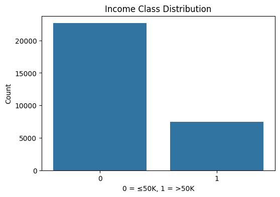

```python
# =====================================================
# 1.b) QUICK EXPLORATORY CHECK
# =====================================================

print("\n" + "="*60)
print("1.b) QUICK EXPLORATORY CHECK")
print("="*60)

# Target distribution (counts)
counts = df_clean["high_income"].value_counts()
percentages = df_clean["high_income"].value_counts(normalize=True) * 100

print("\nTarget Distribution (Counts):")
print(counts)

print("\nTarget Distribution (Percentages):")
print(percentages.round(2))

# ONE visualization for class balance
plt.figure(figsize=(6,4))
sns.countplot(x="high_income", data=df_clean)
plt.title("Income Class Distribution")
plt.xlabel("0 = ≤50K, 1 = >50K")
plt.ylabel("Count")
plt.show()
```

#### **Result Analysis**

- The dataset is moderately imbalanced, with **75.11% earning ≤50K and only 24.89% earning >50K**, indicating a clear majority class.

# 2. Model Training

This section trains ten classification models using an 80/20 train–test split and the full feature set. It includes baseline linear models, regularized models (Lasso, Ridge, Elastic Net), and ensemble methods such as Random Forest and Gradient Boosting.

### Train-Test Split

```python
# =====================================================
# 2.a) INITIAL TRAIN-TEST SPLIT
# =====================================================
# Define features and target
X = df_model.drop("high_income", axis=1)
y = df_model["high_income"]

# Train-test split
X_train, X_test, y_train, y_test = train_test_split(
    X, y,
    test_size=0.2,
    random_state=42,
    stratify=y
)

print("\nTraining and Testing Shapes:")
print("-" * 30)
print("X_train shape:", X_train.shape)
print("X_test shape:", X_test.shape)
print("y_train shape:", y_train.shape)
print("y_test shape:", y_test.shape)

print("\nClass Distribution in Training Set:")
print(y_train.value_counts())

print("\nClass Distribution in Test Set:")
print(y_test.value_counts())
```

```
Training and Testing Shapes:
------------------------------
X_train shape: (24129, 96)
X_test shape: (6033, 96)
y_train shape: (24129,)
y_test shape: (6033,)

Class Distribution in Training Set:
high_income
0    18123
1     6006
Name: count, dtype: int64

Class Distribution in Test Set:
high_income
0    4531
1    1502
Name: count, dtype: int64
```

#### **Result Analysis**

- The dataset was split into **24,129 training observations and 6,033 testing observations, each with 96 features**, following an 80–20 split.
- The class distribution remains consistent across both sets, preserving the imbalance with roughly **75% ≤50K and 25% >50K**, ensuring proper stratification.

### Model 1: Linear Probability Model (Baseline)

- The Linear Probability Model (LPM) is a simple baseline classifier that applies ordinary least squares regression to a binary outcome.
- Although it is not specifically designed for classification tasks, it provides a useful reference point before applying regularization or more advanced models.

```python
print("="*70)
print("MODEL 1: LINEAR PROBABILITY MODEL (BASELINE)")
print("="*70)

# Train model
lpm = LinearRegression()
lpm.fit(X_train, y_train)

# Predict probabilities
train_probs = lpm.predict(X_train)

# Convert to class labels using 0.5 threshold
train_preds = (train_probs >= 0.5).astype(int)

# Compute training accuracy
train_acc_lpm = accuracy_score(y_train, train_preds)

print(f"Training Accuracy: {train_acc_lpm:.4f}")
```

```
======================================================================
MODEL 1: LINEAR PROBABILITY MODEL (BASELINE)
======================================================================
Training Accuracy: 0.8351
```

#### **Result Analysis**

- Training accuracy is **0.8351**, showing good predictive ability.
- No regularization is applied, so all features influence the model.
- This serves as the **baseline for comparing regularized and advanced models.**

### Model 2: Linear Probability Model with Lasso Regularization

- This model applies Lasso (L1) regularization to the Linear Probability Model. Lasso adds a penalty to the absolute magnitude of coefficients, which can shrink some coefficients to zero and perform implicit feature selection.
- The regularization strength (alpha) is tuned using cross-validation to identify the optimal penalty that balances bias and variance.

```python
print("="*70)
print("MODEL 2: LINEAR PROBABILITY MODEL + LASSO REGULARIZATION")
print("="*70)

# Lasso with cross-validation
lasso_cv = LassoCV(
    cv=5,
    random_state=42,
    max_iter=10000
)

lasso_cv.fit(X_train, y_train)

# Best alpha
best_alpha_lasso = lasso_cv.alpha_

# Predictions
train_probs_lasso = lasso_cv.predict(X_train)

# Convert probabilities to class labels
train_preds_lasso = (train_probs_lasso >= 0.5).astype(int)

# Training accuracy
train_acc_lasso = accuracy_score(y_train, train_preds_lasso)

print(f"Best Alpha (Lasso): {best_alpha_lasso:.4f}")
print(f"Training Accuracy: {train_acc_lasso:.4f}")
```

```
======================================================================
MODEL 2: LINEAR PROBABILITY MODEL + LASSO REGULARIZATION
======================================================================
Best Alpha (Lasso): 0.7288
Training Accuracy: 0.7700
```

#### **Result Analysis**

- Training accuracy is **0.7700**, which is lower than the baseline Linear Probability Model **(0.8351).**
- Lasso applies **L1 regularization**, shrinking coefficients and possibly setting some to zero.
- The optimal **alpha = 0.7288**, indicating a relatively strong regularization penalty.
- The lower accuracy suggests **important predictors may have been overly penalized.**

### Model 3: Linear Probability Model with Ridge Regularization

- This model applies Ridge (L2) regularization to the Linear Probability Model. Ridge penalizes the squared magnitude of coefficients, shrinking them toward zero while keeping all variables in the model.
- The regularization strength (alpha) is tuned using cross-validation.

```python
print("="*70)
print("MODEL 3: LINEAR PROBABILITY MODEL + RIDGE REGULARIZATION")
print("="*70)

# Ridge with cross-validation
ridge_cv = RidgeCV(
    alphas=np.logspace(-3, 3, 50),
    cv=5
)

ridge_cv.fit(X_train, y_train)

# Best alpha
best_alpha_ridge = ridge_cv.alpha_

# Predictions
train_probs_ridge = ridge_cv.predict(X_train)

# Convert to class labels
train_preds_ridge = (train_probs_ridge >= 0.5).astype(int)

# Training accuracy
train_acc_ridge = accuracy_score(y_train, train_preds_ridge)

print(f"Best Alpha (Ridge): {best_alpha_ridge:.4f}")
print(f"Training Accuracy: {train_acc_ridge:.4f}")
```

```
======================================================================
MODEL 3: LINEAR PROBABILITY MODEL + RIDGE REGULARIZATION
======================================================================
Best Alpha (Ridge): 33.9322
Training Accuracy: 0.8343
```

#### **Result Analysis**

- Training accuracy is **0.8343**, very close to the baseline Linear Probability Model **(0.8351)**.
- Ridge applies **L2 regularization**, shrinking coefficients but keeping all features.
- The optimal **alpha = 33.9322**, indicating strong regularization.
- The model remains **stable while maintaining similar predictive performance.**

### Model 4: Linear Probability Model with Elastic Net Regularization

- Elastic Net combines both L1 (Lasso) and L2 (Ridge) penalties. This allows the model to shrink coefficients like Ridge while also performing feature selection like Lasso.
- Both the regularization strength (alpha) and the L1/L2 balance (l1_ratio) are tuned using cross-validation.

```python
print("="*70)
print("MODEL 4: LINEAR PROBABILITY MODEL + ELASTIC NET REGULARIZATION")
print("="*70)

# Elastic Net with cross-validation
elastic_cv = ElasticNetCV(
    l1_ratio=[0.1, 0.3, 0.5, 0.7, 0.9],
    alphas=np.logspace(-3, 3, 50),
    cv=5,
    random_state=42,
    max_iter=10000
)

elastic_cv.fit(X_train, y_train)

# Best parameters
best_alpha_en = elastic_cv.alpha_
best_l1_ratio = elastic_cv.l1_ratio_

# Predictions
train_probs_en = elastic_cv.predict(X_train)

# Convert probabilities to class labels
train_preds_en = (train_probs_en >= 0.5).astype(int)

# Training accuracy
train_acc_en = accuracy_score(y_train, train_preds_en)

print(f"Best Alpha (Elastic Net): {best_alpha_en:.4f}")
print(f"Best l1_ratio: {best_l1_ratio:.4f}")
print(f"Training Accuracy: {train_acc_en:.4f}")
```

```
======================================================================
MODEL 4: LINEAR PROBABILITY MODEL + ELASTIC NET REGULARIZATION
======================================================================
Best Alpha (Elastic Net): 0.0010
Best l1_ratio: 0.1000
Training Accuracy: 0.8342
```

#### **Result Analysis**

- Training accuracy is **0.8342**, very close to the baseline Linear Probability Model **(0.8351)**.
- Elastic Net combines **L1 (Lasso) and L2 (Ridge) regularization**.
- The optimal **alpha = 0.0010 and l1_ratio = 0.10**, meaning the model behaves closer to **Ridge**.
- The model keeps similar performance while **slightly stabilizing the coefficients.**

### Model 5: Logistic Regression (Baseline)

- Logistic Regression models the probability of belonging to a class using the logistic function. Unlike the Linear Probability Model, predicted probabilities are always between 0 and 1.
- This baseline version does not apply regularization.

```python
print("="*70)
print("MODEL 5: LOGISTIC REGRESSION (BASELINE)")
print("="*70)

# Logistic Regression without regularization
logit = LogisticRegression(
    penalty=None,
    max_iter=10000
)

logit.fit(X_train, y_train)

# Predict probabilities
train_probs_logit = logit.predict_proba(X_train)[:,1]

# Convert to class labels
train_preds_logit = (train_probs_logit >= 0.5).astype(int)

# Training accuracy
train_acc_logit = accuracy_score(y_train, train_preds_logit)

print(f"Training Accuracy: {train_acc_logit:.4f}")
```

```
======================================================================
MODEL 5: LOGISTIC REGRESSION (BASELINE)
======================================================================
Training Accuracy: 0.8464
```

#### **Result Analysis**

- Training accuracy is **0.8464**, higher than the Linear Probability Model.
- Logistic Regression models probabilities using the **logistic function**, keeping values between 0 and 1.
- No regularization is applied, so all features influence the model.
- The higher accuracy suggests **Logistic Regression fits the classification problem better than LPM**.

### Model 6: Logistic Regression with Lasso (L1) Regularization

- This model applies L1 regularization to Logistic Regression. L1 regularization shrinks coefficients and may set some of them to zero, which performs automatic feature selection.
- The regularization strength is controlled by parameter C, which is tuned using cross-validation.

```python
print("="*70)
print("MODEL 6: LOGISTIC REGRESSION + LASSO (L1)")
print("="*70)

# Logistic Regression with L1 regularization and cross-validation
logit_lasso = LogisticRegressionCV(
    penalty='l1',
    solver='saga',
    cv=5,
    scoring='accuracy',
    max_iter=10000,
    random_state=42
)

logit_lasso.fit(X_train, y_train)

# Best C value
best_C_lasso = logit_lasso.C_[0]

# Predictions
train_probs_logit_lasso = logit_lasso.predict_proba(X_train)[:,1]

# Convert probabilities to class labels
train_preds_logit_lasso = (train_probs_logit_lasso >= 0.5).astype(int)

# Training accuracy
train_acc_logit_lasso = accuracy_score(y_train, train_preds_logit_lasso)

print(f"Best C (Lasso): {best_C_lasso:.4f}")
print(f"Training Accuracy: {train_acc_logit_lasso:.4f}")
```

```
======================================================================
MODEL 6: LOGISTIC REGRESSION + LASSO (L1)
======================================================================
Best C (Lasso): 0.0464
Training Accuracy: 0.7880
```

#### **Result Analysis**

- Training accuracy is **0.7880**, lower than the baseline Logistic Regression **(0.8464)**.
- Lasso applies **L1 regularization**, shrinking coefficients and possibly setting some to zero.
- The optimal **C = 0.0464**, indicating **strong regularization**.
- The lower accuracy suggests **important features may have been overly penalized.**

### Model 7: Logistic Regression with Ridge (L2) Regularization

- This model applies L2 regularization to Logistic Regression. Ridge shrinks coefficients toward zero but keeps all features in the model.
- The regularization strength is controlled by parameter C, which is tuned using cross-validation.

```python
print("="*70)
print("MODEL 7: LOGISTIC REGRESSION + RIDGE (L2)")
print("="*70)

# Logistic Regression with L2 regularization and cross-validation
logit_ridge = LogisticRegressionCV(
    penalty='l2',
    solver='lbfgs',
    cv=5,
    scoring='accuracy',
    max_iter=10000,
    random_state=42
)

logit_ridge.fit(X_train, y_train)

# Best C value
best_C_ridge = logit_ridge.C_[0]

# Predictions
train_probs_logit_ridge = logit_ridge.predict_proba(X_train)[:,1]

# Convert probabilities to class labels
train_preds_logit_ridge = (train_probs_logit_ridge >= 0.5).astype(int)

# Training accuracy
train_acc_logit_ridge = accuracy_score(y_train, train_preds_logit_ridge)

print(f"Best C (Ridge): {best_C_ridge:.4f}")
print(f"Training Accuracy: {train_acc_logit_ridge:.4f}")
```

```
======================================================================
MODEL 7: LOGISTIC REGRESSION + RIDGE (L2)
======================================================================
Best C (Ridge): 21.5443
Training Accuracy: 0.8460
```

#### **Result Analysis**

- Training accuracy is **0.8460,** almost the same as the baseline **Logistic Regression (0.8464).**
- Ridge applies **L2 regularization**, shrinking coefficients but keeping all features.
- The optimal **C = 21.5443**, indicating **weak regularization.**
- The model maintains **similar performance while slightly stabilizing the coefficients.**

### Model 8: Logistic Regression with Elastic Net Regularization

- Elastic Net combines both L1 (Lasso) and L2 (Ridge) penalties. This allows the model to shrink coefficients while also performing feature selection.
- The parameters C and l1_ratio are tuned using cross-validation.

```python
print("="*70)
print("MODEL 8: LOGISTIC REGRESSION + ELASTIC NET")
print("="*70)

# Logistic Regression with Elastic Net regularization
logit_en = LogisticRegressionCV(
    penalty='elasticnet',
    solver='saga',
    l1_ratios=[0.1, 0.3, 0.5, 0.7, 0.9],
    cv=5,
    scoring='accuracy',
    max_iter=10000,
    random_state=42
)

logit_en.fit(X_train, y_train)

# Best parameters
best_C_en = logit_en.C_[0]
best_l1_ratio_en = logit_en.l1_ratio_[0]

# Predictions
train_probs_logit_en = logit_en.predict_proba(X_train)[:,1]

# Convert probabilities to class labels
train_preds_logit_en = (train_probs_logit_en >= 0.5).astype(int)

# Training accuracy
train_acc_logit_en = accuracy_score(y_train, train_preds_logit_en)

print(f"Best C (Elastic Net): {best_C_en:.4f}")
print(f"Best l1_ratio: {best_l1_ratio_en:.4f}")
print(f"Training Accuracy: {train_acc_logit_en:.4f}")
```

```
======================================================================
MODEL 8: LOGISTIC REGRESSION + ELASTIC NET
======================================================================
Best C (Elastic Net): 0.0060
Best l1_ratio: 0.1000
Training Accuracy: 0.7880
```

#### **Result Analysis**

- Training accuracy is **0.7880**, lower than the baseline **Logistic Regression (0.8464)**.
- Elastic Net combines **L1 and L2 regularization**, shrinking coefficients and allowing feature selection.
- The optimal **C = 0.0060 and l1_ratio = 0.10**, indicating **strong regularization with behavior closer to Ridge.**
- The lower accuracy suggests **regularization may be too strong for this model.**

### Model 9: Random Forest with Hyperparameter Tuning

- Random Forest is an ensemble learning method that builds many decision trees and combines their predictions. This reduces variance and improves model stability.
- Hyperparameters are tuned using RandomizedSearchCV to efficiently search for good combinations.

```python
print("="*70)
print("MODEL 9: RANDOM FOREST (HYPERPARAMETER TUNING)")
print("="*70)

# Random Forest base model
rf = RandomForestClassifier(random_state=42)

# Hyperparameter search space
param_dist = {
    "n_estimators": [100, 200, 300],
    "max_depth": [None, 10, 20, 30],
    "min_samples_split": [2, 5, 10],
    "min_samples_leaf": [1, 2, 4],
    "max_features": ["sqrt", "log2"]
}

# Randomized Search
rf_search = RandomizedSearchCV(
    rf,
    param_distributions=param_dist,
    n_iter=20,
    cv=5,
    scoring="accuracy",
    random_state=42,
    n_jobs=-1
)

rf_search.fit(X_train, y_train)

# Best model
best_rf = rf_search.best_estimator_

# Best parameters
best_params_rf = rf_search.best_params_

# Predictions
train_preds_rf = best_rf.predict(X_train)

# Training accuracy
train_acc_rf = accuracy_score(y_train, train_preds_rf)

print("Best Parameters:", best_params_rf)
print(f"Training Accuracy: {train_acc_rf:.4f}")
```

```
======================================================================
MODEL 9: RANDOM FOREST (HYPERPARAMETER TUNING)
======================================================================
Best Parameters: {'n_estimators': 200, 'min_samples_split': 2, 'min_samples_leaf': 2, 'max_features': 'sqrt', 'max_depth': 30}
Training Accuracy: 0.8947
```

#### **Result Analysis**

- Training accuracy is **0.8947, the highest so far among the models.**
- Random Forest builds **many decision trees and averages their predictions**, improving stability.
- Hyperparameters were tuned to find the **best tree depth and sampling settings.**
- The higher accuracy suggests **ensemble methods capture complex patterns better than linear models.**

### Model 10: Gradient Boosting with Hyperparameter Tuning

- Gradient Boosting is an ensemble learning method that builds decision trees sequentially.
- Each new tree focuses on correcting the errors made by the previous trees.
- Hyperparameters are tuned using RandomizedSearchCV to efficiently search for good parameter combinations.

```python
print("="*70)
print("MODEL 10: GRADIENT BOOSTING (HYPERPARAMETER TUNING)")
print("="*70)

# Base model
gb = GradientBoostingClassifier(random_state=42)

# Hyperparameter search space
param_dist_gb = {
    "n_estimators": [100, 200, 300],
    "learning_rate": [0.01, 0.05, 0.1, 0.2],
    "max_depth": [3, 4, 5],
    "min_samples_split": [2, 5, 10],
    "min_samples_leaf": [1, 2, 4],
    "subsample": [0.8, 1.0]
}

# Randomized search
gb_search = RandomizedSearchCV(
    gb,
    param_distributions=param_dist_gb,
    n_iter=20,
    cv=5,
    scoring="accuracy",
    random_state=42,
    n_jobs=-1
)

gb_search.fit(X_train, y_train)

# Best model
best_gb = gb_search.best_estimator_

# Best parameters
best_params_gb = gb_search.best_params_

# Predictions
train_preds_gb = best_gb.predict(X_train)

# Training accuracy
train_acc_gb = accuracy_score(y_train, train_preds_gb)

print("Best Parameters:", best_params_gb)
print(f"Training Accuracy: {train_acc_gb:.4f}")
```

```
======================================================================
MODEL 10: GRADIENT BOOSTING (HYPERPARAMETER TUNING)
======================================================================
Best Parameters: {'subsample': 1.0, 'n_estimators': 200, 'min_samples_split': 10, 'min_samples_leaf': 4, 'max_depth': 4, 'learning_rate': 0.1}
Training Accuracy: 0.8799
```

#### **Result Analysis**

- Training accuracy is **0.8799**, higher than most linear models but lower than Random Forest (0.8947).
- Gradient Boosting builds **trees sequentially**, where each tree corrects previous errors.
- Hyperparameters were tuned to find the **best learning rate, depth, and tree settings.**
- The strong performance shows **boosting captures complex patterns better than simple models.**

### Summary Table

```python
summary_table = pd.DataFrame({

    "Model": [
        "LPM (Baseline)",
        "LPM + Lasso",
        "LPM + Ridge",
        "LPM + Elastic Net",
        "Logistic Regression (Baseline)",
        "Logistic Regression + Lasso",
        "Logistic Regression + Ridge",
        "Logistic Regression + Elastic Net",
        "Random Forest",
        "Gradient Boosting"
    ],

    "Training Accuracy": [
        train_acc_lpm,
        train_acc_lasso,
        train_acc_ridge,
        train_acc_en,
        train_acc_logit,
        train_acc_logit_lasso,
        train_acc_logit_ridge,
        train_acc_logit_en,
        train_acc_rf,
        train_acc_gb
    ],

    "Key Hyperparameters": [
        "None",
        f"alpha={best_alpha_lasso:.4f}",
        f"alpha={best_alpha_ridge:.4f}",
        f"alpha={best_alpha_en:.4f}, l1_ratio={best_l1_ratio:.2f}",
        "None",
        f"C={best_C_lasso:.4f}",
        f"C={best_C_ridge:.4f}",
        f"C={best_C_en:.4f}, l1_ratio={best_l1_ratio_en:.2f}",
        f"n_estimators={best_params_rf['n_estimators']}, max_depth={best_params_rf['max_depth']}",
        f"n_estimators={best_params_gb['n_estimators']}, learning_rate={best_params_gb['learning_rate']}"
    ]

})
summary_table["Training Accuracy"] = summary_table["Training Accuracy"].round(4)
summary_table
```

|  | Model | Training Accuracy | Key Hyperparameters |
| --- | --- | --- | --- |
| 0 | LPM (Baseline) | 0.8351 | None |
| 1 | LPM + Lasso | 0.7700 | alpha=0.7288 |
| 2 | LPM + Ridge | 0.8343 | alpha=33.9322 |
| 3 | LPM + Elastic Net | 0.8342 | alpha=0.0010, l1_ratio=0.10 |
| 4 | Logistic Regression (Baseline) | 0.8464 | None |
| 5 | Logistic Regression + Lasso | 0.7880 | C=0.0464 |
| 6 | Logistic Regression + Ridge | 0.8460 | C=21.5443 |
| 7 | Logistic Regression + Elastic Net | 0.7880 | C=0.0060, l1_ratio=0.10 |
| 8 | Random Forest | 0.8947 | n_estimators=200, max_depth=30 |
| 9 | Gradient Boosting | 0.8799 | n_estimators=200, learning_rate=0.1 |

#### **Result Analysis**

- **Random Forest (0.8947)** achieved the **highest training accuracy.**
- **Gradient Boosting (0.8799)** also performed very well.
- **Logistic Regression models (~0.846)** performed better than LPM models.
- **Linear Probability Models (~0.834** showed lower performance than logistic models.
- Strong regularization **(Lasso / Elastic Net)** reduced accuracy in several models.
- Overall, **ensemble methods outperform linear models for this dataset.**

# 3. Feature Importance Analysis

This section analyzes which variables are most influential in predicting income. Feature importance is extracted from coefficient magnitudes for regularized linear models and built-in importance scores for ensemble models.

### a) Top 7 Features for the 8 Models

```python
# Get Feature Names
X = df_model.drop("high_income", axis=1)
feature_names = X.columns

# Function to Extract Top Features (Linear Models)
def get_top_features_linear(model, feature_names, top_n=7):

    coef = np.abs(model.coef_.flatten())

    importance_df = pd.DataFrame({
        "Feature": feature_names,
        "Importance": coef
    })

    top_features = importance_df.sort_values(
        by="Importance", ascending=False
    ).head(top_n)

    return top_features["Feature"].values


# Function for Tree Models
def get_top_features_tree(model, feature_names, top_n=7):

    importance_df = pd.DataFrame({
        "Feature": feature_names,
        "Importance": model.feature_importances_
    })

    top_features = importance_df.sort_values(
        by="Importance", ascending=False
    ).head(top_n)

    return top_features["Feature"].values

# Extract Top 7 for Each Model
top_features = pd.DataFrame({

"Model 2 (LPM + Lasso)": get_top_features_linear(lasso_cv, feature_names),

"Model 3 (LPM + Ridge)": get_top_features_linear(ridge_cv, feature_names),

"Model 4 (LPM + Elastic Net)": get_top_features_linear(elastic_cv, feature_names),

"Model 6 (Logit + Lasso)": get_top_features_linear(logit_lasso, feature_names),

"Model 7 (Logit + Ridge)": get_top_features_linear(logit_ridge, feature_names),

"Model 8 (Logit + Elastic Net)": get_top_features_linear(logit_en, feature_names),

"Model 9 (Random Forest)": get_top_features_tree(best_rf, feature_names),

"Model 10 (Gradient Boosting)": get_top_features_tree(best_gb, feature_names)

})

top_features
```

|  | Model 2 (LPM + Lasso) | Model 3 (LPM + Ridge) | Model 4 (LPM + Elastic Net) | Model 6 (Logit + Lasso) | Model 7 (Logit + Ridge) | Model 8 (Logit + Elastic Net) | Model 9 (Random Forest) | Model 10 (Gradient Boosting) |
| --- | --- | --- | --- | --- | --- | --- | --- | --- |
| 0 | age | marital.status_Married-civ-spouse | marital.status_Married-civ-spouse | capital.loss | marital.status_Married-civ-spouse | capital.loss | capital.gain | marital.status_Married-civ-spouse |
| 1 | hours.per.week | relationship_Not-in-family | relationship_Wife | capital.gain | relationship_Wife | capital.gain | marital.status_Married-civ-spouse | capital.gain |
| 2 | capital.loss | relationship_Wife | relationship_Not-in-family | hours.per.week | relationship_Own-child | hours.per.week | education.num | education.num |
| 3 | capital.gain | occupation_Exec-managerial | occupation_Exec-managerial | age | occupation_Farming-fishing | age | age | capital.loss |
| 4 | fnlwgt | relationship_Unmarried | workclass_Self-emp-not-inc | fnlwgt | occupation_Other-service | education.num | hours.per.week | age |
| 5 | education.num | workclass_Self-emp-not-inc | relationship_Unmarried | education.num | occupation_Exec-managerial | fnlwgt | fnlwgt | hours.per.week |
| 6 | workclass_Local-gov | relationship_Own-child | occupation_Farming-fishing | marital.status_Never-married | sex_Male | marital.status_Never-married | marital.status_Never-married | occupation_Exec-managerial |

### b) Feature Importance Analysis Interpretation

- `Which features appear consistently in the top 7 across most models?` **Several features consistently appear among the top predictors across many models.** These include **capital.gain, capital.loss, hours.per.week, age, education.num, and marital.status_Married-civ-spouse**. Their repeated presence across both linear and ensemble models suggests that they strongly influence income prediction. **This consistency indicates that these variables contain reliable signals related to higher income levels.**
- `Are there any features that only appear important in certain models? What might explain this?` **Some features appear important only in specific models**, such as **occupation_Farming-fishing or occupation_Other-service**. This occurs because **different model types capture patterns differently**. Linear models highlight variables with strong linear relationships, while **tree-based models detect nonlinear relationships and interactions between variables**. As a result, some predictors may appear important only under certain modeling approaches.
- `What does consistency (or inconsistency) across models tell us about the usefulness of a feature?` **Features that appear consistently across models are likely strong and reliable predictors of income.** Their importance across multiple modeling techniques suggests that their relationship with the target variable is stable. In contrast, **features that appear inconsistently may depend on interactions or nonlinear patterns** that only certain models can capture. This helps identify which variables are universally important versus model-specific signals.

# 4. Model Performance Evaluation

This section evaluates model performance using predictions on the test set. Confusion matrices and classification metrics such as accuracy, precision, recall, F1-score, specificity, and error rates are used to compare all models.

### a) Confusion Matrices

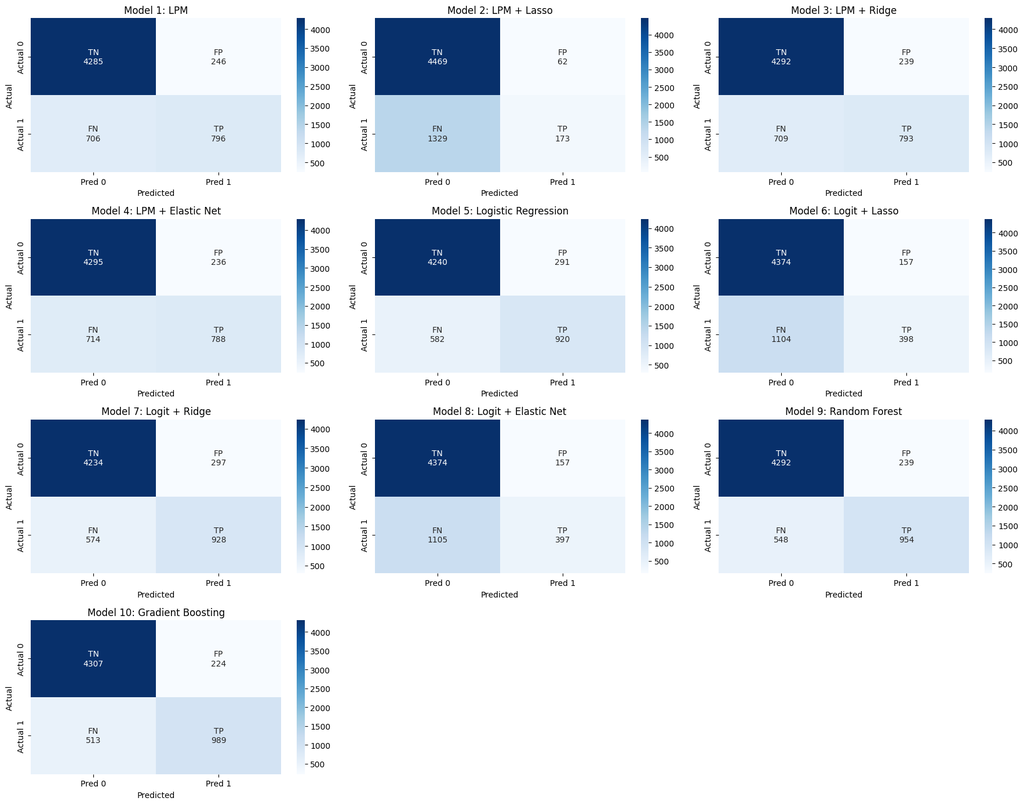

```python
plt.figure(figsize=(18,14))

def plot_cm(ax, y_true, y_pred, title):

    cm = confusion_matrix(y_true, y_pred)
    tn, fp, fn, tp = cm.ravel()

    labels = np.array([
        [f"TN\n{tn}", f"FP\n{fp}"],
        [f"FN\n{fn}", f"TP\n{tp}"]
    ])

    sns.heatmap(
        cm,
        annot=labels,
        fmt="",
        cmap="Blues",
        xticklabels=["Pred 0","Pred 1"],
        yticklabels=["Actual 0","Actual 1"],
        ax=ax
    )

    ax.set_title(title)
    ax.set_xlabel("Predicted")
    ax.set_ylabel("Actual")


# ---- Predictions ----

preds = [
    ( (lpm.predict(X_test) >= 0.5).astype(int), "Model 1: LPM"),
    ( (lasso_cv.predict(X_test) >= 0.5).astype(int), "Model 2: LPM + Lasso"),
    ( (ridge_cv.predict(X_test) >= 0.5).astype(int), "Model 3: LPM + Ridge"),
    ( (elastic_cv.predict(X_test) >= 0.5).astype(int), "Model 4: LPM + Elastic Net"),
    ( (logit.predict_proba(X_test)[:,1] >= 0.5).astype(int), "Model 5: Logistic Regression"),
    ( (logit_lasso.predict_proba(X_test)[:,1] >= 0.5).astype(int), "Model 6: Logit + Lasso"),
    ( (logit_ridge.predict_proba(X_test)[:,1] >= 0.5).astype(int), "Model 7: Logit + Ridge"),
    ( (logit_en.predict_proba(X_test)[:,1] >= 0.5).astype(int), "Model 8: Logit + Elastic Net"),
    ( best_rf.predict(X_test), "Model 9: Random Forest"),
    ( best_gb.predict(X_test), "Model 10: Gradient Boosting")
]

# ---- Plot ----

for i, (pred, title) in enumerate(preds):

    ax = plt.subplot(4,3,i+1)
    plot_cm(ax, y_test, pred, title)

plt.tight_layout()
plt.show()
```

### b) Metrics Table

```python
# Metric Function
def compute_metrics(y_true, y_pred):

    tn, fp, fn, tp = confusion_matrix(y_true, y_pred).ravel()

    accuracy = (tp + tn) / (tp + tn + fp + fn)
    precision = tp / (tp + fp)
    recall = tp / (tp + fn)

    specificity = tn / (tn + fp)

    f1 = 2 * (precision * recall) / (precision + recall)

    type1 = fp / (fp + tn)
    type2 = fn / (fn + tp)

    return accuracy, precision, recall, f1, specificity, type1, type2

# Compute Metrics for All Models
metrics_results = []

for model_name, preds in model_predictions.items():

    accuracy, precision, recall, f1, specificity, type1, type2 = compute_metrics(y_test, preds)

    metrics_results.append([
        model_name,
        accuracy,
        precision,
        recall,
        f1,
        specificity,
        type1,
        type2
    ])

metrics_table = pd.DataFrame(metrics_results, columns=[
    "Model",
    "Accuracy",
    "Precision",
    "Recall",
    "F1-Score",
    "Specificity",
    "Type I Error (FPR)",
    "Type II Error (FNR)"
])

metrics_table.round(4)
```

|  | Model | Accuracy | Precision | Recall | F1-Score | Specificity | Type I Error (FPR) | Type II Error (FNR) |
| --- | --- | --- | --- | --- | --- | --- | --- | --- |
| 0 | Model 1: LPM | 0.8422 | 0.7639 | 0.5300 | 0.6258 | 0.9457 | 0.0543 | 0.4700 |
| 1 | Model 2: LPM + Lasso | 0.7694 | 0.7362 | 0.1152 | 0.1992 | 0.9863 | 0.0137 | 0.8848 |
| 2 | Model 3: LPM + Ridge | 0.8429 | 0.7684 | 0.5280 | 0.6259 | 0.9473 | 0.0527 | 0.4720 |
| 3 | Model 4: LPM + Elastic Net | 0.8425 | 0.7695 | 0.5246 | 0.6239 | 0.9479 | 0.0521 | 0.4754 |
| 4 | Model 5: Logistic Regression | 0.8553 | 0.7597 | 0.6125 | 0.6782 | 0.9358 | 0.0642 | 0.3875 |
| 5 | Model 6: Logit + Lasso | 0.7910 | 0.7171 | 0.2650 | 0.3870 | 0.9653 | 0.0347 | 0.7350 |
| 6 | Model 7: Logit + Ridge | 0.8556 | 0.7576 | 0.6178 | 0.6806 | 0.9345 | 0.0655 | 0.3822 |
| 7 | Model 8: Logit + Elastic Net | 0.7908 | 0.7166 | 0.2643 | 0.3862 | 0.9653 | 0.0347 | 0.7357 |
| 8 | Model 9: Random Forest | 0.8696 | 0.7997 | 0.6352 | 0.7080 | 0.9473 | 0.0527 | 0.3648 |
| 9 | Model 10: Gradient Boosting | 0.8778 | 0.8153 | 0.6585 | 0.7285 | 0.9506 | 0.0494 | 0.3415 |

### c) Regularization Impact on Linear Probability Model

- `Did regularization improve accuracy, precision, recall, or F1?` **Regularization did not meaningfully improve the LPM models.** Accuracy stayed almost the same for Ridge and Elastic Net **(~0.842)**, while Lasso reduced accuracy and recall significantly.
- `Did any model reduce Type I or Type II errors meaningfully?` **Lasso greatly reduced Type I errors (FPR = 0.0137) but increased Type II errors (FNR = 0.8848).** This means the model avoided false positives but missed many true positive cases.
- `Why may regularization have helped or not helped for LPM?` **Regularization had limited benefit for LPM** because the baseline model already performed reasonably well. **Ridge and Elastic Net only slightly adjusted coefficients**, so performance stayed similar. **Lasso applied strong feature selection**, which removed useful predictors and reduced recall. As a result, **the model missed many positive cases**. This shows that aggressive regularization can hurt performance when important variables are removed.

### d) Regularization Impact on Logistic Regression

- `Did regularization improve any metric?` **Ridge slightly improved Logistic Regression performance**, increasing accuracy from **0.8553 to 0.8556** and improving recall.
- `Which regularization type performed best for Logistic Regression?` **Ridge regularization performed best**, maintaining high accuracy and balanced precision and recall.
- `Discussion` Regularization had different effects across the logistic models. **Ridge slightly improved the model** by shrinking coefficients while keeping all predictors. **Lasso and Elastic Net reduced recall significantly** because they removed important features. This **increased Type II errors and lowered overall performance**. Therefore, **moderate regularization (Ridge) worked best for this dataset.**

### e) Best Linear Model vs Ensemble Model

- `Best model from linear group (Models 1–4):` **Linear Probability Model + Ridge** (Accuracy = **0.8429**)
- `Best model from logistic group (Models 5–8):` **Logistic Regression + Ridge** (Accuracy = **0.8556**)
- `Which group performs best overall?` **Ensemble models perform best.** **Gradient Boosting** achieved the **highest accuracy (0.8778)** followed by **Random Forest (0.8696)**, showing stronger performance than linear and logistic models.

# 5. Model Recommendation and Justification

This section identifies the best model based on empirical results. It explains the final model recommendation, evaluates trade-offs between performance and interpretability, and reflects on insights from regularization and ensemble methods.

### a) Recommended Model

- `Top Recommended Model:` **Gradient Boosting is the best model.** It achieves the highest accuracy (**0.8778**), highest precision (**0.8153**), highest recall (**0.6585**), and highest F1-score (**0.7285**). It also has the lowest Type II error (**0.3415**) and a low Type I error (**0.0494**).
- `Second-Best Alternative:` **Random Forest is a strong backup.** It performs slightly lower than Gradient Boosting but remains stable with high accuracy (**0.8696**) and strong F1-score (**0.7080**).
- `Performance vs Interpretability:` **Gradient Boosting provides the best predictive performance**, but it is less interpretable than linear models like Logistic Regression. However, the performance gains justify the reduced interpretability for prediction tasks.
- `Error Trade-off in Income Prediction:` In income prediction, **Type II errors (missing high-income individuals)** are often more costly because they hide important signals about high earners. Gradient Boosting aligns with this goal by achieving the **lowest Type II error rate (0.3415)** among all models.

### b) Reflection

- `Role of Regularization:` **Regularization helped stabilize the linear models** by shrinking coefficients and reducing overfitting risk. However, it **did not significantly improve overall performance** for this dataset. **Ridge slightly improved Logistic Regression**, while **Lasso and Elastic Net often reduced recall and overall accuracy**. This suggests the dataset benefits more from keeping most predictors rather than aggressively removing them.
- `Random Forest vs Gradient Boosting:` **Gradient Boosting would be preferred for deployment** because it achieved the highest accuracy (**0.8778**) and F1-score (**0.7285**) while maintaining strong precision and recall. Random Forest is still valuable because it trains faster and is easier to tune. However, when predictive performance is the main priority, Gradient Boosting provides better results.
- `Explaining the Model to Non-Technical Stakeholders:` The model works by **learning patterns from past data to predict whether someone earns a high income**. It analyzes many factors such as age, education, work hours, and capital gains to identify patterns linked to higher earnings. By combining many decision trees, the model improves accuracy and reduces mistakes compared with simpler models. We trust the model because it consistently performs best across multiple evaluation metrics and handles complex relationships in the data effectively.

# 6. References

1. **Scikit-learn Documentation.** Pedregosa, F., et al. (2011). *Scikit-learn: Machine Learning in Python.* Journal of Machine Learning Research. https://scikit-learn.org
2. **Course Notebook / Lecture Material.** *Regularization Methods Notebook* (HTML file provided in DSA4155 course materials). University of Santo Tomas.
3. **ChatGPT (AI Assistance).** OpenAI. (2026). *ChatGPT (GPT-5) – Assistance for conceptual explanation, debugging, and code structuring.* https://chat.openai.com